# anSeq R package

Blanca Pijuan-Sala

09 October 2018

## Introduction

This package provides a toolkit for analysing single-cell RNA-seq data.

First, let’s load the library.

```r
library(anSeq)
```

Next, we will also process a specific dataset provided in the package with the proSeq package so that we get our normalised log2 transformed counts. If you would like further information on the proSeq package, please refer to it at https://github.com/BPijuanSala/proSeq

```r
library(proSeq)
```

[output not shown]

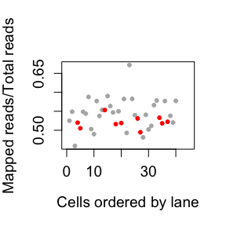

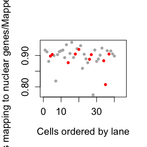

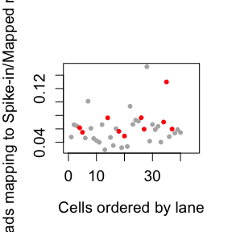

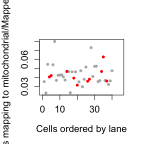

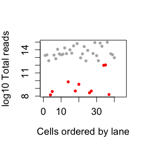

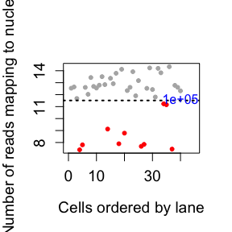

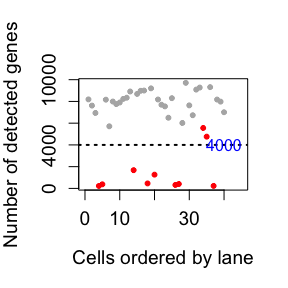

```
## DONE!
```

```r
##Split counts into gene counts and feature counts
countsfeat = countsMatrix[grep("^__",rownames(countsMatrix)),]
rownames(countsfeat) = c("no.feature","ambiguous","lowQuality","unaligned","align.not.unique")
countsRaw = countsMatrix[grep("^__",rownames(countsMatrix),invert = TRUE),]


##Find ERCC spike-ins

spikes = substr(rownames(countsRaw),1,4)=="ERCC"
names(spikes)=rownames(countsRaw)

##Create RNAseq object

meta = meta[rownames(meta)%in%colnames(countsRaw),]
countsRaw <- countsRaw[,colnames(countsRaw)%in%rownames(meta)]
meta <- meta[colnames(countsRaw),]
countsfeat1 <- countsfeat[,colnames(countsRaw)]

data <- new("RNAseq", countsRaw=as.matrix(countsRaw), metadata=as.matrix(meta),SpikeIn=spikes,CountsFeat=as.matrix(countsfeat1))

#Perform cell QC
cellQC_data <- runCellQC(data,checkCountsFeat = TRUE,plotting="no",maxMapmit=0.12,minGenesExpr = 4000,minMapreads = 100000)
```

```r
cellsFailQC(data)<-c(cellQC_data)

# Normalise counts
NormOutput1 <- normalise(data)
```

```
## Setting up variables...
##
## Computing size factors...
##
## Plotting size factors against library size (should be correlated) ...
```

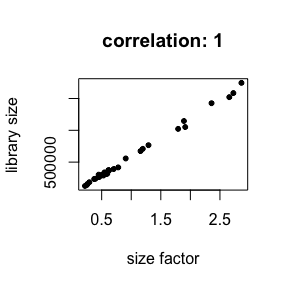

```
## DONE!
```

```
## Estimating technical noise...
##
## Plotting fit...
```

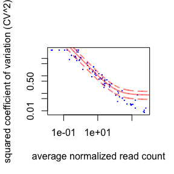

```
## Calculating biological variance...
##
## Plotting highly variable genes...
```

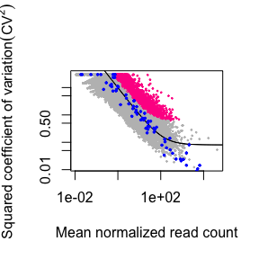

```r
countsNorm(data) <- NormOutput1$countsNorm

CellsSizeFac(data) <- list(sizeFactorsGenes = NormOutput1$sizeFactorsGenes,
                             sizeFactorsSpikeIn = NormOutput1$sizeFactorsSpikeIn)

# Find highly variable genes
hvg <- findHVG(object=data,plotting="no",UseSpike = TRUE, minQuantMeans = 0.1,maxQuantMeans = 0.9,maxQuantCv2 = 0.9,minQuantCv2 = 0.1)
```

```r
genesHVG(data) = hvg
```

## Functions

### Find the gene name of a geneID or viceversa

You can find the Ensembl Gene ID of a particular gene with the “getGeneID” function. This function returns a list with two elements. The first one is a table where you can find the gene ID and the associated gene name. The second is a vector with the geneID directly.

```r
geneName <- getGeneID(c("Tal1","Spi1"))

geneName[[1]] #table
```

```
##                  Gene.ID Associated.Gene.Name
## 30750 ENSMUSG00000028717                 Tal1
## 8406  ENSMUSG00000002111                 Spi1
```

```r
geneName[[2]]#geneID vector
```

```
## [1] "ENSMUSG00000028717" "ENSMUSG00000002111"
```

The default table used to find the corresponding geneID is the object geneTable, which you can access just by doing:

```r
head(geneTable)
```

```
##              Gene.ID Associated.Gene.Name
## 1 ENSMUSG00000064372                mt-Tp
## 2 ENSMUSG00000064371                mt-Tt
## 3 ENSMUSG00000064370              mt-Cytb
## 4 ENSMUSG00000064369                mt-Te
## 5 ENSMUSG00000064368               mt-Nd6
## 6 ENSMUSG00000064367               mt-Nd5
```

This dataframe is based on GRCm38.81 annotation (mouse mm10). You can change the table by specifying the argument “Table”. In this argument, you have to provide a table like geneTable (i.e. with first column of geneID and second of geneName).

```r
geneName <- getGeneID(c("Tal1","Spi1"),Table=geneTable)
```

You can find tables in bioMart https://www.ensembl.org/biomart/martview/95b29a51b58327ef22ed69b6c23d28b9

```r
geneID <- getGeneName(c("ENSMUSG00000028717", "ENSMUSG00000002111"),Table=geneTable)

geneID[[1]]
```

```
##                               Gene.ID Associated.Gene.Name
## ENSMUSG00000028717 ENSMUSG00000028717                 Tal1
## ENSMUSG00000002111 ENSMUSG00000002111                 Spi1
```

```r
geneID[[2]]
```

```
## [1] "Tal1" "Spi1"
```

### Select cells in a plot

First, we compute PCA on log2 transformed normalised counts

```r
#Take normalised counts
normCounts <- countsNorm(data)
counts <- log2(normCounts+1)



pca <- prcomp(t(counts[hvg,]))
```

Next, we feed the PCA into the function “selectCellsinPlot”. This will make a window pop up. With the mouse, gate the cells you are interested in by left clicking and finally right-click to finish.

```r
cells <- selectCellsinPlot(pca$x[,c(1:2)],pch=20)

as.vector(cells)
```

This will return a vector of cell names and also the x and y coordinates of the points of interest. You can then use the cell names for further explorations.

### Find markers

Sometimes, we want to find markers of specific populations. For this, we can use the function “findMarkers”, which makes use of edgeR for differential expression analyses.

First, we need to create a vector as long as the number of cells to analyse, with the groups we are interested and named them by the cell. Next, we run the function. If the dataset is very big, I would recommend making a selection of highly variable genes in the dataset first and then run the function.

```r
metaPassQC <- meta[colnames(counts),]
groups <- metaPassQC$celltype
names(groups)<- rownames(metaPassQC)

markers <- findMarkers(counts,groups=groups)
```

```
##
##
##
## Comparing YS to others...
## Estimating dispersions...Disp = 1e-04 , BCV = 0.01
##
##
##
## Comparing AL to others...
## Estimating dispersions...Disp = 1e-04 , BCV = 0.01
```

The output of this function is a list with the different groups that you have compared. Each element will have a dataframe with the results for the comparison between that group against the rest. Those genes with positive logFC will be those upregulated in that group.

You can also use findMarkers in a more targeted manner. If you are interested in a specific population only, for example, YS, you can run the following.

```r
markers <- findMarkers(counts,groups=groups,groupTarget = "YS")
```

```
##
##
##
## Comparing YS to others...
## Estimating dispersions...Disp = 1e-04 , BCV = 0.01
```

### Check for surface markers

A popular question in science is whether a particular cell population has cell surface markers that are unique for them so that we can purify it. Here, I have taken a list of surface markers from http://wlab.ethz.ch/cspa/ so that you can check whether you gene list contains any surface markers.

```r
surface <- findSurfaceMarkers(markers$YS)
```

This function returns a vector with cell surface genes as names and the confidence category of them being a surface protein as element.

### Check gene expression levels

To assess gene levels in a landscape, you can use ‘plotGeneLevels’

```r
plotGeneLevels(counts,x=pca$x[,1],y=pca$x[,2],gene=getGeneID("Tal1")[[2]],
               titlePlot = "Tal1")
```

[output not shown]

We can also check the expression levels by group with boxplots doing the following. This will output both the PCA coloured by gene expression and the boxplots of gene expression divided by groups.

```r
colorsGroups <- moduleColor::labels2colors(as.numeric(as.factor(groups)))
plotGeneLevels(counts,x=pca$x[,1],y=pca$x[,2],gene=getGeneID("Tal1")[[2]],
               titlePlot = "Tal1",boxplot = T,clusters=colorsGroups)
```

[output not shown]

### Hierarchical clustering with optimal leaf reordering

We can use hclustCells to cluster cells based on hierarchical clustering and leaf reordering.

```r
countsForClust <- counts[hvg,]
clust <- anSeq::hclustCells(countsForClust,leafreorder="column")
```

### Random forest classifier

If we want to classify a set of cells using random forests, we can train the forest using “trainForest” and allocate the cells with “allocateCellsForest”. *Note that the cell numbers here are very low; this should only serve as example.

We first define cells for training. You should have similar numbers of groups. In this case, we have 10 cells for YS and 10 cells for AL.

```r
trainCellsYS <- sample(rownames(metaPassQC)[metaPassQC$celltype=="YS"],10)
trainCellsAL <- sample(rownames(metaPassQC)[metaPassQC$celltype=="AL"],10)
```

Next, we define cells to classify (we should imagine we don’t know which celltypes these cells are)

```r
mysterious <- rownames(metaPassQC)[rownames(metaPassQC)%in%c(trainCellsAL,trainCellsYS)==F]
```

Set up data to train random forest on

```r
dataTrain <- counts[,c(trainCellsYS,trainCellsAL)]
groupsTrain <- c(rep("YS",length(trainCellsYS)),rep("AL",length(trainCellsAL)))
names(groupsTrain)<-colnames(dataTrain)
```

Train random forest

```r
training <- trainForest(dataTrain,groups=groupsTrain)
```

```
## Ranking data...
## Training preliminary forest...
## Ranking data...
## Growing forest...
```

Once the random forest is trained, we classify our mysterious cells

```r
dataToClass <- counts[,mysterious]
Classification <- allocateCellsForest(dataToClass,RForestObj = training$RForest,genesTrained = training$genesTrained)
```

I hope this was useful. If you have any issues, please report them to bps.queries@gmail.com